- Автор: Морозова Влада Викторовна

# Разработка A/B-тестирования и анализ результатов

Исследование данных развлекательного приложения с функцией «бесконечной» ленты. Существует две модели монетизации: первая — ежемесячная платная подписка, которая позволяет пользователям смотреть ленту без рекламы, вторая — демонстрация рекламы для пользователей, которые ещё не оформили подписку.

Команда разработчиков рекомендательных систем создала новый алгоритм рекомендаций, который, по их мнению, будет показывать более интересный контент для каждого пользователя. Моя цель рассчитать параметры A/B-теста, который позволит проверить эту гипотезу, и проанализировать его результаты.

## Описание данных

У этих таблиц почти совпадает структура и содержание колонок, различаются лишь периоды наблюдения.

## Цель

Рассчитать параметры теста, оценить корректность его проведения и проанализировать результаты эксперимента.

## Содержимое

1. Работа с историческими данными (EDA)
2. Подготовка к тесту
3. Мониторинг А/В-теста
4. Проверка результатов A/B-теста

### 1. Работа с историческими данными (EDA)

#### 1.1. Загрузка исторических данных

На первом этапе поработаем с историческими данными приложения.

Основная метрика в ходе проведения А/В эксперимента - это увеличение доли сессий с четырьмя и более просмотренными страницами. Необходимо отслеживать число сессий в день (в нашем случае положительный эффект это отсутствие изменения/увеличение). В тест вовлекается все аудитория приложения, т.к. новая опция раскатывается на всех.

```python
import pandas as pd
import numpy as np
import matplotlib.pyplot as plt
import matplotlib.dates as mdates
from pandas.plotting import register_matplotlib_converters
from statsmodels.stats.proportion import proportions_ztest
from scipy.stats import mannwhitneyu
```

```python
sessions_history = pd.read_csv('sessions_project_history.csv', parse_dates = ['session_date', 'session_start_ts', 'install_date'])

display(sessions_history.info(), sessions_history.head())
```

```
<class 'pandas.core.frame.DataFrame'>
RangeIndex: 435924 entries, 0 to 435923
Data columns (total 10 columns):
 #   Column             Non-Null Count   Dtype
---  ------             --------------   -----
 0   user_id            435924 non-null  object
 1   session_id         435924 non-null  object
 2   session_date       435924 non-null  datetime64[ns]
 3   session_start_ts   435924 non-null  datetime64[ns]
 4   install_date       435924 non-null  datetime64[ns]
 5   session_number     435924 non-null  int64
 6   registration_flag  435924 non-null  int64
 7   page_counter       435924 non-null  int64
 8   region             435924 non-null  object
 9   device             435924 non-null  object
dtypes: datetime64[ns](3), int64(3), object(4)
memory usage: 33.3+ MB
```

```
None
```

|  | user_id | session_id | session_date | session_start_ts | install_date | session_number | registration_flag | page_counter | region | device |
| --- | --- | --- | --- | --- | --- | --- | --- | --- | --- | --- |
| 0 | E302123B7000BFE4 | F9AF61A0C2023832 | 2025-08-15 | 2025-08-15 17:47:35 | 2025-08-15 | 1 | 0 | 3 | CIS | iPhone |
| 1 | 2530F72E221829FB | 85003A206CBDAC6F | 2025-08-15 | 2025-08-15 16:42:14 | 2025-08-15 | 1 | 0 | 4 | MENA | Android |
| 2 | 876E020A4FC512F5 | 3677423E49D72DEE | 2025-08-15 | 2025-08-15 12:30:00 | 2025-08-15 | 1 | 0 | 4 | EU | PC |
| 3 | 2640B349E1D81584 | 956B45F5915CA225 | 2025-08-15 | 2025-08-15 15:31:31 | 2025-08-15 | 1 | 0 | 4 | CIS | Android |
| 4 | 94E1CBFAEF1F5EE9 | 83BF0DA35F9F1F40 | 2025-08-15 | 2025-08-15 21:33:53 | 2025-08-15 | 1 | 0 | 3 | CIS | Android |

- В таблице нет пропусков и наименования столбцов корректно отражают данные в них.

#### 1.2. Знакомство с данными

- Для каждого уникального пользователя `user_id` рассчитаем количество уникальных сессий `session_id`.
- Выведем на экран все данные из таблицы `sessions_history` для одного пользователя с наибольшим количеством сессий.
- Изучим таблицу для одного пользователя, чтобы лучше понять логику формирования каждого столбца данных.

```python
number_of_user_sessions = (sessions_history
                                .groupby('user_id')
                                .agg({'session_id': 'nunique'})
                                .sort_values(by='session_id', ascending=False))
display(number_of_user_sessions)
```

| user_id | session_id |
| --- | --- |
| 10E0DEFC1ABDBBE0 | 10 |
| 6A73CB5566BB494D | 10 |
| 8A60431A825D035B | 9 |
| D11541BAC141FB94 | 9 |
| 5BCFE7C4DCC148E9 | 9 |
| ... | ... |
| 1DF13BB1953B3497 | 1 |
| 628502A3CE7E0A3C | 1 |
| 1DEEF40DEFBD0C65 | 1 |
| AC08479B7472C628 | 1 |
| 8A0882B6715D9EE5 | 1 |

134039 rows × 1 columns

```python
top_user = number_of_user_sessions.index[0]

top_user_sessions = sessions_history[sessions_history['user_id'] == top_user]
display(top_user_sessions)
```

|  | user_id | session_id | session_date | session_start_ts | install_date | session_number | registration_flag | page_counter | region | device |
| --- | --- | --- | --- | --- | --- | --- | --- | --- | --- | --- |
| 115558 | 10E0DEFC1ABDBBE0 | B8F0423BBFFCF5DC | 2025-08-14 | 2025-08-14 13:57:39 | 2025-08-14 | 1 | 0 | 4 | CIS | Android |
| 191751 | 10E0DEFC1ABDBBE0 | 87CA2FA549473837 | 2025-08-15 | 2025-08-15 16:42:10 | 2025-08-14 | 2 | 0 | 3 | CIS | Android |
| 239370 | 10E0DEFC1ABDBBE0 | 4ADD8011DCDCE318 | 2025-08-16 | 2025-08-16 19:53:21 | 2025-08-14 | 3 | 0 | 3 | CIS | Android |
| 274629 | 10E0DEFC1ABDBBE0 | DF0FD0E09BF1F3D7 | 2025-08-17 | 2025-08-17 15:03:43 | 2025-08-14 | 4 | 0 | 1 | CIS | Android |
| 302501 | 10E0DEFC1ABDBBE0 | 3C221774B4DE6885 | 2025-08-18 | 2025-08-18 17:29:14 | 2025-08-14 | 5 | 0 | 4 | CIS | Android |
| 325557 | 10E0DEFC1ABDBBE0 | 031BD7A67048105B | 2025-08-19 | 2025-08-19 13:23:55 | 2025-08-14 | 6 | 0 | 2 | CIS | Android |
| 345336 | 10E0DEFC1ABDBBE0 | FF4315CF4AD4B100 | 2025-08-20 | 2025-08-20 19:31:54 | 2025-08-14 | 7 | 0 | 2 | CIS | Android |
| 377532 | 10E0DEFC1ABDBBE0 | 4045FEA0747203B4 | 2025-08-22 | 2025-08-22 17:54:13 | 2025-08-14 | 8 | 0 | 2 | CIS | Android |
| 403538 | 10E0DEFC1ABDBBE0 | 344B086C421C7F37 | 2025-08-24 | 2025-08-24 14:46:13 | 2025-08-14 | 9 | 0 | 2 | CIS | Android |
| 414743 | 10E0DEFC1ABDBBE0 | 054F20BA371E4C9D | 2025-08-25 | 2025-08-25 18:36:41 | 2025-08-14 | 10 | 0 | 3 | CIS | Android |

- Количество сессий у пользователей варьируется от 1 до 10.
- Мы решили изучить данные одного из пользователей с максимальным количеством сессий и установили, что с момента установки приложения человек посещал его в течение 12 дней (10 раз). Пользователь не зарегистрировался, пользуется Android-устройством, находится в регионе CIS. Начало сессии происходит с часа дня до восьми вечера. Среднее количество просмотренных страниц пользователя составляет ~3.

#### 1.3. Анализ числа регистраций

Одна из важнейших метрик продукта — число зарегистрированных пользователей. Визуализируем, как менялось число регистраций в приложении за время его существования.

- Отобразим линейные графики общего числа пользователей и общего числа зарегистрированных пользователей по дням, а также отдельный линейный график доли зарегистрированных пользователей от всех пользователей по дням.

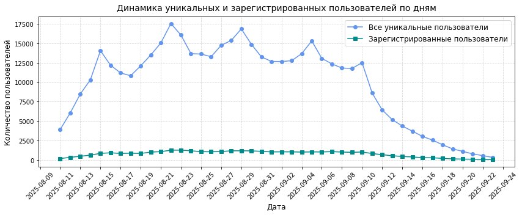

```python
daily_stats = sessions_history.copy().sort_values('session_date')

daily_users = (daily_stats
               .groupby('session_date')['user_id']
               .nunique()
               .reset_index(name='total_users'))

daily_reg_users = (daily_stats[daily_stats['registration_flag'] == 1]
                   .groupby('session_date')['user_id']
                   .nunique()
                   .reset_index(name='reg_users'))

result = pd.merge(daily_users, daily_reg_users, on='session_date', how='left').fillna(0)

plt.figure(figsize=(12, 5))
ax = plt.gca()

plt.plot(result['session_date'], result['total_users'],
         label='Все уникальные пользователи', marker='o', color='#6495ED')
plt.plot(result['session_date'], result['reg_users'],
         label='Зарегистрированные пользователи', marker='s', color='#008B8B')

ax.xaxis.set_major_locator(mdates.DayLocator(interval=2))
ax.xaxis.set_major_formatter(mdates.DateFormatter('%Y-%m-%d'))
plt.xticks(rotation=45)

plt.xlabel('Дата', fontsize=12)
plt.ylabel('Количество пользователей', fontsize=12)
plt.title('Динамика уникальных и зарегистрированных пользователей по дням', pad=10, fontsize=14)
plt.legend(fontsize=12)
plt.grid(True, linestyle='--', alpha=0.5)

plt.tight_layout()
plt.show()
```

- В начале и в конце рассматриваемого периода метрики общего числа уникальных пользователей демонстрируют резкие изменения, в то время как в середине цикла наблюдаются колебания.
- Количество уникальных зарегистрированных пользователей остаётся стабильным и визуализируется в виде практически прямой линии.

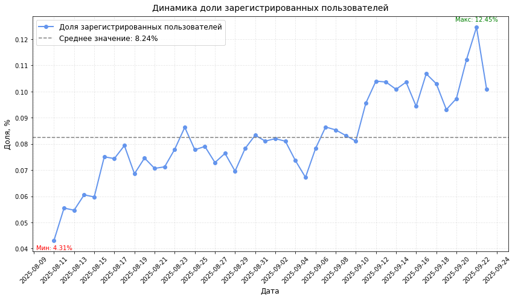

```python
result['reg_perc'] = result['reg_users'] / result['total_users']

mean_reg_perc = result['reg_perc'].mean()
max_day = result.loc[result['reg_perc'].idxmax()]
min_day = result.loc[result['reg_perc'].idxmin()]

plt.figure(figsize=(12, 7))
ax = plt.gca()

plt.plot(result['session_date'], result['reg_perc'],
         label='Доля зарегистрированных пользователей',
         marker='o',
         color='#6495ED',
         linewidth=2,
         markersize=6)

plt.axhline(mean_reg_perc, color='gray', linestyle='--', linewidth=1.5, label=f'Среднее значение: {mean_reg_perc:.2%}')

plt.annotate(f"Макс: {max_day['reg_perc']:.2%}",
             xy=(max_day['session_date'], max_day['reg_perc']),
             xytext=(0, 10), textcoords='offset points',
             ha='center', fontsize=10, color='green')

plt.annotate(f"Мин: {min_day['reg_perc']:.2%}",
             xy=(min_day['session_date'], min_day['reg_perc']),
             xytext=(0, -15), textcoords='offset points',
             ha='center', fontsize=10, color='red')

ax.xaxis.set_major_locator(mdates.DayLocator(interval=2))
ax.xaxis.set_major_formatter(mdates.DateFormatter('%Y-%m-%d'))
plt.xticks(rotation=45)

plt.xlabel('Дата', fontsize=12)
plt.ylabel('Доля, %', fontsize=12)
plt.title('Динамика доли зарегистрированных пользователей', pad=10, fontsize=14)
plt.legend(fontsize=12)
plt.grid(True, linestyle='--', alpha=0.3)

plt.tight_layout()
plt.show()
```

- На графиках чётко видно, что абсолютные значения и доля зарегистрированных пользователей значительно ниже общего числа клиентов. Однако можно выделить тренд на рост регистраций в период с августа по сентябрь текущего года.

#### 1.4. Анализ числа просмотренных страниц

Другая важная метрика продукта — число просмотренных страниц в приложении. Чем больше страниц просмотрено, тем сильнее пользователь увлечён контентом, а значит, выше шансы на то, что он зарегистрируется и оплатит подписку.

- Найдем количество сессий для каждого значения количества просмотренных страниц и построим столбчатую диаграмму.

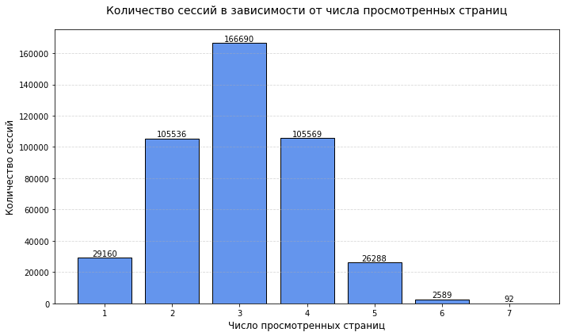

```python
sessions_per_page = (sessions_history
                     .groupby('page_counter')['session_id']
                     .count()
                     .reset_index(name='total_sessions')
                     .sort_values('page_counter'))

plt.figure(figsize=(10, 6))

bars = plt.bar(sessions_per_page['page_counter'], sessions_per_page['total_sessions'], color='#6495ED', edgecolor='k')

for bar in bars:
    plt.text(bar.get_x() + bar.get_width()/2, bar.get_height(),
             str(bar.get_height()),
             ha='center', va='bottom')

plt.title('Количество сессий в зависимости от числа просмотренных страниц', pad=20, fontsize=14)
plt.xlabel('Число просмотренных страниц', fontsize=12)
plt.ylabel('Количество сессий', fontsize=12)
plt.grid(True, axis='y',linestyle='--', alpha=0.5)

plt.tight_layout()
plt.show()
```

- Большинство пользователей просматривают от 2 до 4 страниц за сессию, что указывает на стандартное взаимодействие с платформой.
- Особое внимание следует уделить пользователям, ограничивающимся просмотром только 1 страницы. Необходимо проанализировать причины такой низкой вовлечённости:
1. Сложность навигации
2. Нерелевантные рекомендации контента
3. Технические ошибки (долгая загрузка, баги интерфейса)
- Группа, просматривающая более 5 страниц за сессию (менее 30 000 пользователей), вероятно, включает:
1. Зарегистрированных пользователей
2. Пользователи с подпиской
3. Целевую аудиторию с высокой заинтересованностью

#### 1.5. Доля пользователей, просмотревших более четырёх страниц

Сессии, в рамках которых пользователь просмотрел 4 и более страниц, говорят об удовлетворённости контентом и алгоритмами рекомендаций. Этот показатель является важной прокси-метрикой для продукта.

- В датафрейме `sessions_history` создадим дополнительный столбец `good_session`. В него войдёт значение `1`, если за одну сессию было просмотрено 4 и более страниц, и значение `0`, если было просмотрено меньше.
- Построим график со средним значением доли успешных сессий ко всем сессиям по дням за весь период наблюдения.

```
Среднее за весь период: 0.31
Среднее за последний период: 0.3
Стандартное отклонение: 0.0069
```

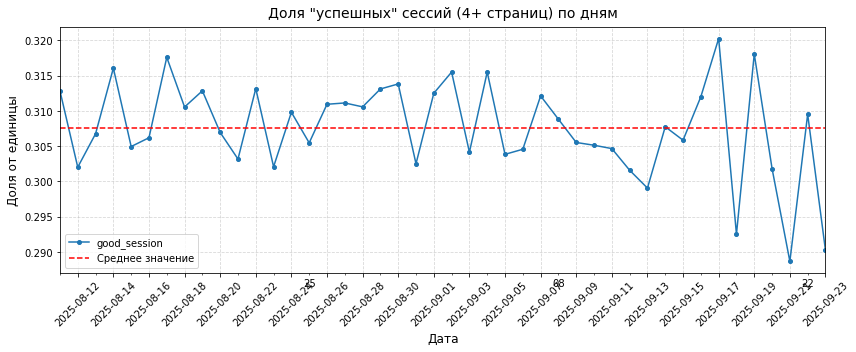

```python
sessions_history['good_session'] = (sessions_history['page_counter'] >= 4).astype(int)

daily_good_sessions = (sessions_history
                       .groupby('session_date')['good_session']
                       .mean()
                       .sort_index())

mean_all = daily_good_sessions.mean()

mean_last_period = daily_good_sessions.tail(7).mean()

print(f"Среднее за весь период: {mean_all:.2}")
print(f"Среднее за последний период: {mean_last_period:.2}")

std_dev = daily_good_sessions.std()
print(f"Стандартное отклонение: {std_dev:.4f}")

plt.figure(figsize=(12, 5))
ax = daily_good_sessions.plot(kind='line', marker='o', markersize=4)

plt.axhline(mean_all, color='red', linestyle='--', label="Среднее значение")

ax.xaxis.set_major_formatter(mdates.DateFormatter('%Y-%m-%d'))
ax.xaxis.set_major_locator(mdates.DayLocator(interval=2))
plt.xticks(rotation=45)

plt.title('Доля "успешных" сессий (4+ страниц) по дням', pad=10, fontsize=14)
plt.xlabel('Дата', fontsize=12)
plt.ylabel('Доля от единицы', fontsize=12)
plt.grid(True, linestyle='--', alpha=0.5)
plt.legend()
plt.tight_layout()

plt.show()
```

- Доля успешных сессий (4+ страниц) стабильно колеблется вокруг 0.3 (30%), что свидетельствует о предсказуемом уровне вовлечённости пользователей.
- Наблюдаются регулярные колебания, что может быть связано с:
1. Изменениями поведения аудитории (выходные/будни)
2. Влиянием маркетинговых активностей
- Резкие скачки в конце сентября требуют отдельного внимания, возможные причины:
1. Технические сбои (падение серверов, ошибки загрузки контента)
2. Изменения в приложениии
3. Внешние факторы (конкуренция, сезонность)

### 2. Подготовка к тесту

При планировании теста необходимо проделать несколько важных шагов:

- Определиться с целевой метрикой.
- Рассчитать необходимый размер выборки.
- Исходя из текущих значений трафика, рассчитать необходимую длительность проведения теста.

#### 2.1. Расчёт размера выборки

Параметры:

- Уровень значимости — 0.05.
- Вероятность ошибки второго рода — 0.2.
- MDE — 3%.

```python
from statsmodels.stats.power import NormalIndPower

alpha = 0.05
beta = 0.2
power = 1 - beta
mde = 0.03

power_analysis = NormalIndPower()

sample_size = power_analysis.solve_power(
    effect_size=mde,
    power=power,
    alpha=alpha,
    ratio=1
)

print(f"Необходимый размер выборки для каждой группы: {int(sample_size)}")
```

```
Необходимый размер выборки для каждой группы: 17441
```

#### 2.1. Расчёт длительности A/B-теста

- Определим длительность теста, исходя из рассчитанного значения размера выборок и среднего дневного трафика приложения.

```python
from math import ceil

avg_daily_users = ceil(sessions_history.groupby('session_date')['user_id'].nunique().mean())

sample_size = sample_size * 2
test_duration = ceil(sample_size / avg_daily_users)

print(f"Рассчитанная длительность A/B-теста при текущем уровене трафика в {avg_daily_users} пользователей в день составит {test_duration} дней")
```

```
Рассчитанная длительность A/B-теста при текущем уровене трафика в 9908 пользователей в день составит 4 дней
```

- Размер каждой выборки составил 17441 пользователь, для достижения этой цели тест следует проводить в течение четырех дней.

### 3. Мониторинг А/В-теста

#### 3.1. Проверка распределения пользователей

- Рассчитаем процентную разницу в количестве пользователей в группах A и B и построим визуализацию, на которой можно было бы увидеть возможное различие двух групп.

Для расчёта процентной разницы формула: $$P = 100 \cdot \frac{|A − B|}{A}$$

```python
sessions_test_part = pd.read_csv('sessions_project_test_part.csv', parse_dates = ['session_date', 'session_start_ts', 'install_date'])

display(sessions_test_part.info(), sessions_test_part.head())
```

```
<class 'pandas.core.frame.DataFrame'>
RangeIndex: 3130 entries, 0 to 3129
Data columns (total 11 columns):
 #   Column             Non-Null Count  Dtype
---  ------             --------------  -----
 0   user_id            3130 non-null   object
 1   session_id         3130 non-null   object
 2   session_date       3130 non-null   datetime64[ns]
 3   session_start_ts   3130 non-null   datetime64[ns]
 4   install_date       3130 non-null   datetime64[ns]
 5   session_number     3130 non-null   int64
 6   registration_flag  3130 non-null   int64
 7   page_counter       3130 non-null   int64
 8   region             3130 non-null   object
 9   device             3130 non-null   object
 10  test_group         3130 non-null   object
dtypes: datetime64[ns](3), int64(3), object(5)
memory usage: 269.1+ KB
```

```
None
```

|  | user_id | session_id | session_date | session_start_ts | install_date | session_number | registration_flag | page_counter | region | device | test_group |
| --- | --- | --- | --- | --- | --- | --- | --- | --- | --- | --- | --- |
| 0 | 3404844B53442747 | B4901323BD537E45 | 2025-10-14 | 2025-10-14 19:28:49 | 2025-10-14 | 1 | 0 | 3 | CIS | Android | B |
| 1 | 3A2BF4D364E62D89 | 216FC619308F8788 | 2025-10-14 | 2025-10-14 21:11:04 | 2025-10-14 | 1 | 0 | 3 | MENA | iPhone | A |
| 2 | 79CDAE11E32B1597 | EDFCE4AC1A504074 | 2025-10-14 | 2025-10-14 21:44:03 | 2025-10-14 | 1 | 0 | 3 | CIS | iPhone | A |
| 3 | D6AF8D78297A931F | CF0AC0EEDE92C690 | 2025-10-14 | 2025-10-14 19:07:55 | 2025-10-14 | 1 | 0 | 4 | CIS | PC | A |
| 4 | 37E0CE723AE568E0 | 2E6ED45E8C86C4E9 | 2025-10-14 | 2025-10-14 15:39:44 | 2025-10-14 | 1 | 0 | 3 | CIS | Mac | B |

```python
total_users_A = sessions_test_part[sessions_test_part['test_group'] == 'A']['user_id'].nunique()
total_users_B = sessions_test_part[sessions_test_part['test_group'] == 'B']['user_id'].nunique()

print(f'Размер выборки А: {total_users_A} юзеров, размер выборки В: {total_users_B}')
```

```
Размер выборки А: 1477 юзеров, размер выборки В: 1466
```

```python
perc_diff = round(100 * (total_users_A - total_users_B)/ total_users_A, 2)

print(f'Процентная разница между выборками А и В составляет: {perc_diff}%')
```

```
Процентная разница между выборками А и В составляет: 0.74%
```

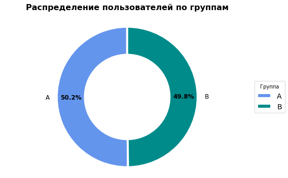

```python
users_for_group = sessions_test_part.groupby('test_group')['user_id'].nunique()

plt.figure(figsize=(8, 5))

colors = ['cornflowerblue', 'darkcyan']

wedges, texts, autotexts = plt.pie(users_for_group,
                                   labels=users_for_group.index,
                                   colors=colors, autopct='%1.1f%%',
                                   startangle=90,
                                   wedgeprops={'width': 0.4,
                                    'edgecolor': 'white', 'linewidth': 4},
                                   textprops={'fontsize': 12},
                                   pctdistance=0.80)

plt.title('Распределение пользователей по группам', fontsize=16, fontweight='bold', pad=20)
plt.ylabel('')
plt.axis('equal')
plt.legend(wedges, users_for_group.index, title="Группа", fontsize=14, loc="center left", bbox_to_anchor=(1, 0.5))
plt.tight_layout()

for autotext in autotexts:
    autotext.set_fontsize(12)
    autotext.set_fontweight('bold')

plt.show()
```

- Процентная разница в количестве пользователей между выборками составляет менее 1%. Этим различием можно пренебречь и продолжить тест.

#### 3.2. Проверка пересечений пользователей

Убедимся в том, что никто из пользователей случайно не попал в обе группы одновременно.

```python
users_A = sessions_test_part[sessions_test_part['test_group'] == 'A']['user_id']
users_B = sessions_test_part[sessions_test_part['test_group'] == 'B']['user_id']

intersection = list(set(users_A) & set(users_B))
print(f'Пользователи, которые встречаются одновременно в группах A и B: {intersection}')
```

```
Пользователи, которые встречаются одновременно в группах A и B: []
```

#### 3.3. Равномерность разделения пользователей по устройствам

Проверим распределение пользователей по всем доступным категориальным переменным — типам устройства и регионам.

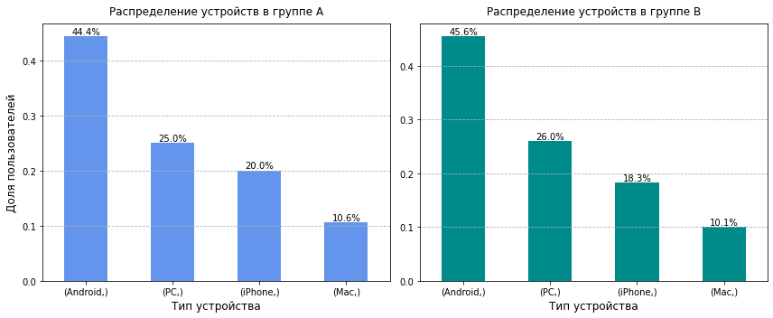

```python
devices_A = (
    sessions_test_part[sessions_test_part['test_group'] == 'A']
    .drop_duplicates('user_id')[['device']]
    .value_counts(normalize=True))

devices_B = (
    sessions_test_part[sessions_test_part['test_group'] == 'B']
    .drop_duplicates('user_id')[['device']]
    .value_counts(normalize=True))

fig, (ax1, ax2) = plt.subplots(1, 2, figsize=(12, 5))

bars_A = devices_A.plot(kind='bar', ax=ax1, color='cornflowerblue', rot=0)
ax1.set_title('Распределение устройств в группе А', pad=10)
ax1.set_xlabel('Тип устройства', fontsize=12)
ax1.set_ylabel('Доля пользователей', fontsize=12)
ax1.grid(axis='y', linestyle='--')

for bar in bars_A.patches:
    height = bar.get_height()
    ax1.text(
        bar.get_x() + bar.get_width() / 2,
        height,
        f'{height:.1%}',
        ha='center', va='bottom', fontsize=10)

bars_B = devices_B.plot(kind='bar', ax=ax2, color='darkcyan', rot=0)
ax2.set_title('Распределение устройств в группе В', pad=10)
ax2.set_xlabel('Тип устройства', fontsize=12)
ax2.grid(axis='y', linestyle='--')

for bar in bars_B.patches:
    height = bar.get_height()
    ax2.text(
        bar.get_x() + bar.get_width() / 2,
        height,
        f'{height:.1%}',
        ha='center', va='bottom', fontsize=10)

plt.tight_layout()
plt.show()
```

```python
devices = ['Android', 'iPhone', 'PC', 'Mac']

contingency_table = pd.crosstab(
    sessions_test_part.drop_duplicates('user_id')['test_group'],
    sessions_test_part.drop_duplicates('user_id')['device']
)

# Н0: Вероятность равномерного распределения пользователей с устройством равны между группами А и В - Ра = Рb
# Н1: Вероятность равномерного распределения пользователей с устройством не равны между группами А и В - Ра != Рb

results = []
for device in devices:
    count = np.array([
        contingency_table.loc['A', device],
        contingency_table.loc['B', device]
    ])

    nobs = np.array([
        contingency_table.loc['A'].sum(),
        contingency_table.loc['B'].sum()
    ])

    z_stat, p_value = proportions_ztest(count, nobs, alternative='two-sided')

    results.append({
        'Устройство': device,
        'Z-статистика': f"{z_stat:.3f}",
        'p-value': f"{p_value:.4f}",
        'Отвергаем Н0': 'Да' if p_value < 0.05 else 'Нет'
    })

results_df = pd.DataFrame(results)
display(results_df)
```

|  | Устройство | Z-статистика | p-value | Отвергаем Н0 |
| --- | --- | --- | --- | --- |
| 0 | Android | -0.628 | 0.5300 | Нет |
| 1 | iPhone | 1.165 | 0.2441 | Нет |
| 2 | PC | -0.626 | 0.5312 | Нет |
| 3 | Mac | 0.416 | 0.6776 | Нет |

#### 3.4. Равномерность распределения пользователей по регионам

Теперь убедимся, что пользователи равномерно распределены по регионам.

[figure not shown]

```python
regions_A = (
    sessions_test_part[sessions_test_part['test_group'] == 'A']
    .drop_duplicates('user_id')[['region']]
    .value_counts(normalize=True))

regions_B = (
    sessions_test_part[sessions_test_part['test_group'] == 'B']
    .drop_duplicates('user_id')[['region']]
    .value_counts(normalize=True))

fig, (ax1, ax2) = plt.subplots(1, 2, figsize=(12, 6))

ax1.pie(
    regions_A, labels=regions_A.index,
    autopct='%1.1f%%', startangle=90,
    colors=['cornflowerblue', 'darkcyan', 'crimson'],
    textprops={'fontsize': 12})

ax1.set_title('Доля регионов в группе А', pad=20, fontsize=14, fontweight='bold')

ax2.pie(
    regions_B, labels=regions_B.index,
    autopct='%1.1f%%', startangle=90,
    colors=['cornflowerblue', 'darkcyan', 'crimson'],
    textprops={'fontsize': 12})

ax2.set_title('Доля регионов в группе А', pad=20, fontsize=14, fontweight='bold')

plt.suptitle('Распределение регионов пользователей в группах', y=1.05, fontsize=16)
plt.tight_layout()
plt.show()
```

```python
regions = ['CIS', 'MENA', 'EU']

contingency_table = pd.crosstab(
    sessions_test_part.drop_duplicates('user_id')['test_group'],
    sessions_test_part.drop_duplicates('user_id')['region']
)

# Н0: Вероятность равномерного распределения пользователей с регионом равны между группами А и В - Ра = Рb
# Н1: Вероятность равномерного распределения пользователей с регионом не равны между группами А и В - Ра != Рb

results = []
for region in regions:
    count = np.array([
        contingency_table.loc['A', region],
        contingency_table.loc['B', region]
    ])

    nobs = np.array([
        contingency_table.loc['A'].sum(),
        contingency_table.loc['B'].sum()
    ])

    z_stat, p_value = proportions_ztest(count, nobs, alternative='two-sided')

    results.append({
        'Регион': region,
        'Z-статистика': f"{z_stat:.3f}",
        'p-value': f"{p_value:.4f}",
        'Отвергаем Н0': 'Да' if p_value < 0.05 else 'Нет'
    })

results_df = pd.DataFrame(results)
display(results_df)
```

|  | Регион | Z-статистика | p-value | Отвергаем Н0 |
| --- | --- | --- | --- | --- |
| 0 | CIS | -0.216 | 0.8289 | Нет |
| 1 | MENA | 0.017 | 0.9861 | Нет |
| 2 | EU | 0.276 | 0.7822 | Нет |

### 4. Проверка результатов A/B-теста

A/B-тест завершён, есть результаты за все дни проведения эксперимента. Необходимо убедиться в корректности теста и верно интерпретировать результаты.

#### 4.1. Получение результатов теста и подсчёт основной метрики

```python
sessions_test = pd.read_csv('sessions_project_test.csv', parse_dates = ['session_date', 'session_start_ts', 'install_date'])

sessions_test['good_session'] = (sessions_test['page_counter'] >= 4).astype(int)

sessions_test.info()
sessions_test.head()
```

```
<class 'pandas.core.frame.DataFrame'>
RangeIndex: 100005 entries, 0 to 100004
Data columns (total 12 columns):
 #   Column             Non-Null Count   Dtype
---  ------             --------------   -----
 0   user_id            100005 non-null  object
 1   session_id         100005 non-null  object
 2   session_date       100005 non-null  datetime64[ns]
 3   session_start_ts   100005 non-null  datetime64[ns]
 4   install_date       100005 non-null  datetime64[ns]
 5   session_number     100005 non-null  int64
 6   registration_flag  100005 non-null  int64
 7   page_counter       100005 non-null  int64
 8   region             100005 non-null  object
 9   device             100005 non-null  object
 10  test_group         100005 non-null  object
 11  good_session       100005 non-null  int32
dtypes: datetime64[ns](3), int32(1), int64(3), object(5)
memory usage: 8.8+ MB
```

|  | user_id | session_id | session_date | session_start_ts | install_date | session_number | registration_flag | page_counter | region | device | test_group | good_session |
| --- | --- | --- | --- | --- | --- | --- | --- | --- | --- | --- | --- | --- |
| 0 | 6DAE3B3654DA738E | C69249E26E58F6E2 | 2025-10-26 | 2025-10-26 18:15:05 | 2025-10-16 | 3 | 0 | 3 | MENA | Android | A | 0 |
| 1 | 0A3FE5D1DD59110A | 66D66D7C9F5181B7 | 2025-10-21 | 2025-10-21 17:04:53 | 2025-10-15 | 2 | 1 | 2 | CIS | Android | B | 0 |
| 2 | 2041F1D7AA740B88 | 50DE51D42215E74C | 2025-10-23 | 2025-10-23 17:39:29 | 2025-10-19 | 3 | 0 | 2 | MENA | Android | A | 0 |
| 3 | 43D7585009168086 | 5763C0C353C22263 | 2025-10-24 | 2025-10-24 15:01:57 | 2025-10-18 | 4 | 0 | 1 | CIS | iPhone | B | 0 |
| 4 | 15AD68B14D62D88C | B1AD09F93C1053BC | 2025-10-17 | 2025-10-17 17:34:39 | 2025-10-17 | 1 | 0 | 2 | MENA | Android | B | 0 |

#### 4.2. Проверка корректности результатов теста

Прежде чем приступать к анализу ключевых продуктовых метрик, необходимо убедиться, что тест проведён корректно и мы будем сравнивать две сопоставимые группы.

- Рассчитаем количество уникальных сессий для каждого дня и обеих тестовых групп, используя группировку.
- Проверим, что количество уникальных дневных сессий в двух выборках не различается или различия не статистически значимы.

Гипотеза:

- $H_0: \mu_{\text{А}} \leq \mu_{\text{В}}$  
  Количество уникальных дневных сессий в двух выборках не различается.
- $H_1: \mu_{\text{В}} > \mu_{\text{А}}$  
  Количество уникальных дневных сессий в двух выборках различается.

```python
sessions_test['session_date'].sort_values().unique()
```

```
array(['2025-10-14T00:00:00.000000000', '2025-10-15T00:00:00.000000000',
       '2025-10-16T00:00:00.000000000', '2025-10-17T00:00:00.000000000',
       '2025-10-18T00:00:00.000000000', '2025-10-19T00:00:00.000000000',
       '2025-10-20T00:00:00.000000000', '2025-10-21T00:00:00.000000000',
       '2025-10-22T00:00:00.000000000', '2025-10-23T00:00:00.000000000',
       '2025-10-24T00:00:00.000000000', '2025-10-25T00:00:00.000000000',
       '2025-10-26T00:00:00.000000000', '2025-10-27T00:00:00.000000000',
       '2025-10-28T00:00:00.000000000', '2025-10-29T00:00:00.000000000',
       '2025-10-30T00:00:00.000000000', '2025-10-31T00:00:00.000000000',
       '2025-11-01T00:00:00.000000000', '2025-11-02T00:00:00.000000000'],
      dtype='datetime64[ns]')
```

```
p-value теста Манна-Уитни =0.8817307917391243
Нулевая гипотеза находит подтверждение!
```

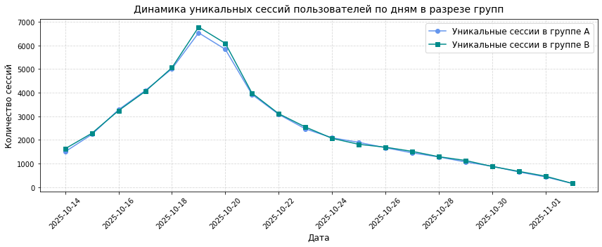

```python
daily_stats = sessions_test.sort_values('session_date')

daily_users_A = (daily_stats[daily_stats.test_group == 'A']
               .groupby('session_date')['session_id']
               .nunique()
               .reset_index(name='total_users_A'))
daily_users_B = (daily_stats[daily_stats.test_group == 'B']
                   .groupby('session_date')['session_id']
                   .nunique()
                   .reset_index(name='total_users_B'))

result = pd.merge(daily_users_A, daily_users_B, on='session_date', how='outer')

test, pvalue_mw = mannwhitneyu(result['total_users_A'], result['total_users_B'])

if pvalue_mw > 0.05:
    print(f'p-value теста Манна-Уитни ={pvalue_mw}')
    print('Нулевая гипотеза находит подтверждение!')
else:
    print(f'p-value теста Манна-Уитни ={pvalue_mw}')
    print('Нулевая гипотеза не находит подтверждения!')

plt.figure(figsize=(12, 5))
ax = plt.gca()

plt.plot(result['session_date'], result['total_users_A'],
         label='Уникальные сессии в группе А', marker='o', color='#6495ED')
plt.plot(result['session_date'], result['total_users_B'],
         label='Уникальные сессии в группе В', marker='s', color='#008B8B')

ax.xaxis.set_major_locator(mdates.DayLocator(interval=2))
ax.xaxis.set_major_formatter(mdates.DateFormatter('%Y-%m-%d'))
plt.xticks(rotation=45)

plt.xlabel('Дата', fontsize=12)
plt.ylabel('Количество сессий', fontsize=12)
plt.title('Динамика уникальных сессий пользователей по дням в разрезе групп', pad=10, fontsize=14)
plt.legend(fontsize=12)
plt.grid(True, linestyle='--', alpha=0.5)

plt.tight_layout()
plt.show()
```

#### 4.3. Сравнение доли успешных сессий

Можно переходить к анализу ключевой метрики — доли успешных сессий. Рассчитаем долю успешных сессий для выборок A и B, а также разницу в этом показателе.

```python
success_rates = (
    sessions_test
    .groupby('test_group')['good_session']
    .mean()
    .reset_index(name='success_rate')
)

diff = (
    success_rates.loc[success_rates['test_group'] == 'B', 'success_rate'].iloc[0] -
    success_rates.loc[success_rates['test_group'] == 'A', 'success_rate'].iloc[0]
)

print("Доли успешных сессий:")
print(success_rates.to_string(index=False))
print(f"\nРазница (B - A): {diff:.2%}")
```

```
Доли успешных сессий:
test_group  success_rate
         A      0.307723
         B      0.318290

Разница (B - A): 1.06%
```

#### 4.4. Насколько статистически значимо изменение ключевой метрики

- Используя статистический тест, подтвердим, является ли изменение в метрике доли успешных сессий статистически значимым.

Гипотеза:

- $H_0: \mu_{\text{А}} \leq \mu_{\text{В}}$  
  Доля успешных сессий (>=4 просмотров) в двух выборках не различается.
- $H_1: \mu_{\text{В}} > \mu_{\text{А}}$  
  Доля успешных сессий (>=4 просмотров) в двух выборках различается, пользователи с новой системой рекомендаций активнее смотрят контент.

```python
count_sessoins = sessions_test.groupby('test_group')['good_session'].agg(['sum', 'count'])

alpha = 0.05

z_test, p_value = proportions_ztest(
    count_sessoins['sum'],
    count_sessoins['count']
)

print(f"Статистическая значимость разницы: p-value = {p_value:.4f}")
if p_value < alpha:
    print("\nРазница статистически значима (p < 0.05).")
else:
    print("\nРазница незначима (p >= 0.05).")
```

```
Статистическая значимость разницы: p-value = 0.0003

Разница статистически значима (p < 0.05).
```

#### 4.5. Вывод по результатам A/B-эксперимента

**Вывод**: Внедрение системы безопасно (не влияет на стабильность) и эффективно (увеличивает вовлечённость).